# Take-home Exercise 1

Creating data visualisation beyond default

Antonius Handy https://www.linkedin.com/in/antoniushandy (Singapore Management University, Master of IT in Business)https://scis.smu.edu.sg/master-it-business  
2022-04-24

# 1. Overview

In this take-home exercise, we are going to reveal the demographic of the city of Engagement, Ohio USA by using appropriate static statistical graphics methods.

The data is processed by using appropriate tidyverse family of packages, whereas the statistical graphics are prepared using ggplot2 and its extensions.

### INTERESTING FACT

Engagement city does not physically exist in Google Maps. It often refers to Urbana which is located halfway between Dayton and Marion (dating and marrying). Source: [*Barry Popik*](https://www.barrypopik.com/index.php/new_york_city/entry/ohio_wheres_engagement)

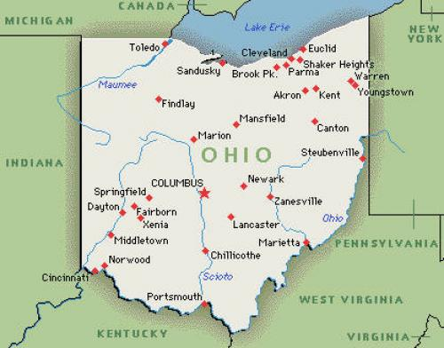

Photo: [*Greenwich Mean Time*](https://greenwichmeantime.com/time-zone/usa/ohio/map/)

# 2. Getting Started

Before we get started, it is important for us to ensure that the required R packages have been installed. If yes, we will load the R packages. If they have yet to be installed, we will install the R packages and load them onto R environment.

The packages required for this exercise are [**tidyverse**](https://www.tidyverse.org/), [**ggdist**](https://mjskay.github.io/ggdist/index.html) and [**hrbrthemes**](https://www.rdocumentation.org/packages/hrbrthemes/versions/0.1.0).

```r
packages = c('tidyverse','ggdist','hrbrthemes')

for(p in packages){
  if(!require(p, character.only = T)){
    install.packages(p)
  }
  library(p, character.only = T)
}
```

# 3. Data

### DATA SOURCE

The original dataset was obtained from [*VAST Challenge 2022*](https://vast-challenge.github.io/2022/index.html) in csv format. It consists of basic information about the residents of Engagement, OH that have agreed to participate in this study.

### IMPORTING DATA

The code chunk below imports dataset into R by using `read_csv()` of **readr** and saves it as a tibble data frame called *demographics*. It consists of 1011 records as shown below.

```r
demographics <- read_csv("data/Participants.csv")
glimpse(demographics)
```

```
Rows: 1,011
Columns: 7
$ participantId  <dbl> 0, 1, 2, 3, 4, 5, 6, 7, 8, 9, 10, 11, 12, 13,~
$ householdSize  <dbl> 3, 3, 3, 3, 3, 3, 3, 3, 3, 3, 3, 3, 3, 3, 3, ~
$ haveKids       <lgl> TRUE, TRUE, TRUE, TRUE, TRUE, TRUE, TRUE, TRU~
$ age            <dbl> 36, 25, 35, 21, 43, 32, 26, 27, 20, 35, 48, 2~
$ educationLevel <chr> "HighSchoolOrCollege", "HighSchoolOrCollege",~
$ interestGroup  <chr> "H", "B", "A", "I", "H", "D", "I", "A", "G", ~
$ joviality      <dbl> 0.001626703, 0.328086500, 0.393469590, 0.1380~
```

### DATA WRANGLING

For easier understanding, the age distribution of the population is further split into 4 broad age groups of similar distribution, namely 30 and below, 31-40, 41-50, and 51 and above.

To do this, `mutate()` of **dplyr** adds a new variable called *age_category* while still preserves the existing variables - *age*.

```r
demographics <- demographics %>%
  mutate(age_category=cut(age,
                          breaks=c(17, 30, 40, 50, 60),
                          labels=c('30 and below','31-40','41-50','51 and above')))
```

# 4. Demographic Visualisation

### STATIC STATISTICAL GRAPH METHODS

Basic statistical graphs are derived from [**ggplot2**](https://ggplot2.tidyverse.org/index.html), such as `geom_bar()` to create a bar chart, `geom_histogram()` to create a histogram, `geom_text()` to display a text, `geom_hline()` to create a horizontal line, and `coord_flip()` to rotate vertical plots into horizontal plots.

Next, we also explore and go beyond basic statistical graphs by using [**ggdist**](https://mjskay.github.io/ggdist/index.html) package, such as `stat_halfeye()` to create a half violin plot, as well as `stat_dots()`.

The label on x-axis, label on y-axis and title are set by `xlab()`, `ylab()` and `ggtitle()` respectively, whereas the base theme used below is `theme_ipsum()` of [**hrbrthemes**](https://www.rdocumentation.org/packages/hrbrthemes/versions/0.1.0) which is an Arial Narrow-based theme.

See Appendix section for more details.

### MARITAL STATUS AND KIDS

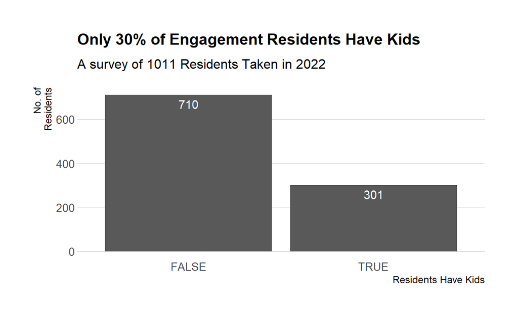

[figure not shown]

### HOW HAPPY ARE ENGAGEMENT RESIDENTS?

Two figures below show the happiness level across different age groups and education levels.

It is observed that the happiness level is almost equally distributed among young adults aged 30 and below, while on the other hand, most of the elderlies seem to be unhappy. In addition, unhappiness is also associated with low-educated residents.

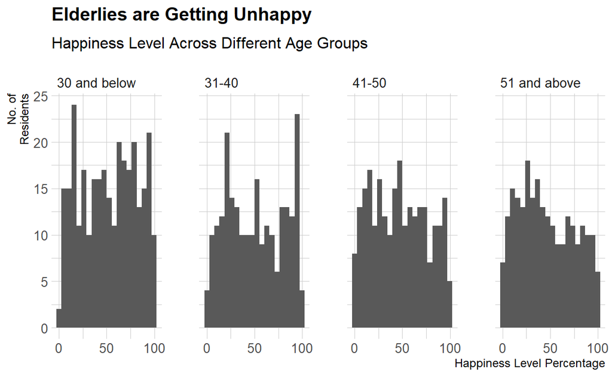

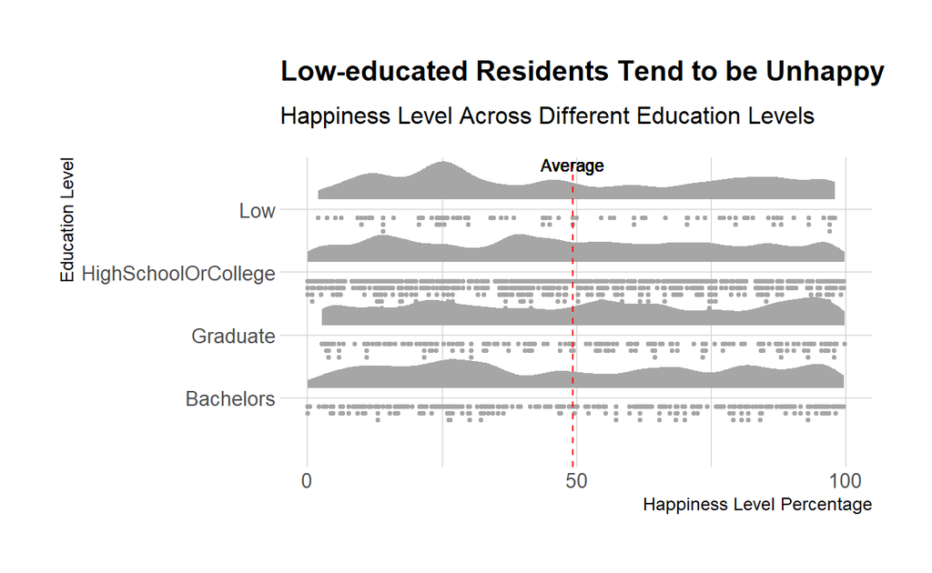

# 5. References

https://isss608-ay2021-22april.netlify.app/hands-on_ex/hands-on_ex01/hands-on_ex01#1

https://isss608-ay2021-22april.netlify.app/hands-on_ex/hands-on_ex02/hands-on_ex02#1

https://rstudio.github.io/distill/basics.html

https://www.r-bloggers.com/2021/09/adding-text-labels-to-ggplot2-bar-chart/

https://www.statology.org/r-create-categorical-variable-from-continuous/

# 6. Appendix

The code chunk below displays the **number of Engagement residents that have kids**.

```r
ggplot(data = demographics,
       aes(x = haveKids)) +
  geom_bar() +
  geom_text(aes(label=..count..),
            stat="count",
            vjust=1.5,
            color="white") +
  xlab("Residents Have Kids") +
  ylab("No. of\nResidents") +
  ggtitle("Only 30% of Engagement Residents Have Kids",
          subtitle = "A survey of 1011 Residents Taken in 2022") +
  theme_ipsum(plot_title_size = 14,
              axis_title_face = 24,
              base_size=10,
              grid="Y")
```

The code chunk below displays the **household distribution** among Engagement residents.

```r
ggplot(data = demographics,
       aes(x = householdSize)) +
  geom_bar() +
  geom_text(aes(label=..count..),
            stat="count",
            vjust=1.5,
            color="white") +
  xlab("Household Size (Persons)") +
  ylab("No. of\nResidents") +
  ggtitle("Most of Households Consist of 2 Person",
          subtitle = "A survey of 1011 Residents Taken in 2022") +
  theme_ipsum(plot_title_size = 14,
              axis_title_face = 24,
              base_size=10,
              grid="Y")
```

The code chunk below displays **happiness level percentage across different age groups**.

```r
ggplot(data = demographics,
       aes(x = joviality*100))+
  geom_histogram(bins=20) +
  facet_grid(~ age_category) +
  xlab("Happiness Level Percentage") +
  ylab("No. of\nResidents") +
  scale_x_continuous(breaks = c(0,50,100)) +
  ggtitle("Elderlies are Getting Unhappy",
          subtitle="Happiness Level Across Different Age Groups") +
  theme_ipsum(plot_title_size = 14,
              axis_title_face = 24,
              strip_text_size = 10,
              base_size=10,
              plot_margin = margin(5,5,5,5))
```

The code chunk below displays **happiness level percentage across different education levels**.

```r
ggplot(data=demographics,
       aes(x = educationLevel, y = joviality*100)) +
  scale_y_continuous(breaks = seq(0, 100, 50),
                     limits = c(0, 100)) +
  stat_halfeye(adjust = .33,
               width = .67,
               color = NA,
               justification = -.01,
               position = position_nudge(
                 x = .15)) +
  stat_dots(side = "left",
            justification = 1.1,
            binwidth = .25,
            dotsize = 5) +
  xlab("Education Level") +
  ylab("Happiness Level\nPercentage") +
  ggtitle("Low-educated Residents Tend to be Unhappy",
          subtitle="Happiness Level Across Different Education Levels") +
  theme_ipsum(plot_title_size = 14,
              axis_title_face = 24,
              strip_text_size = 10,
              base_size=10) +
  geom_hline(aes(yintercept=mean(joviality,
                                 na.rm=T)*100),
             color="red",
             linetype="dashed",
             size=0.5) +
  geom_text(aes(5,mean(joviality)*100,
                label="Average", vjust=-0.5), size=3)+
  coord_flip()
```